# Reproducible Research: Peer Assessment 1

Jesús Pérez

7/30/2020

# Activity monitoring

## 1. Loading and opening the data

```r
## Loading the file as a zip file
path <- getwd()
url <- "https://d396qusza40orc.cloudfront.net/repdata%2Fdata%2Factivity.zip"
download.file(url, destfile = paste(path, "Files.zip", sep = "/"))
unzip(zipfile = "Files.zip")

## Open the data
data <- read.csv("activity.csv", header = TRUE)
str(data)
```

```
## 'data.frame':    17568 obs. of  3 variables:
##  $ steps   : int  NA NA NA NA NA NA NA NA NA NA ...
##  $ date    : Factor w/ 61 levels "2012-10-01","2012-10-02",..: 1 1 1 1 1 1 1 1 1 1 ...
##  $ interval: int  0 5 10 15 20 25 30 35 40 45 ...
```

```r
head(data)
```

```
##   steps       date interval
## 1    NA 2012-10-01        0
## 2    NA 2012-10-01        5
## 3    NA 2012-10-01       10
## 4    NA 2012-10-01       15
## 5    NA 2012-10-01       20
## 6    NA 2012-10-01       25
```

Now we can see some parameters such as maximum, minimum, range and the NA’s values of each variable using the **summary** function.

```r
summary(data)
```

```
##      steps                date          interval
##  Min.   :  0.00   2012-10-01:  288   Min.   :   0.0
##  1st Qu.:  0.00   2012-10-02:  288   1st Qu.: 588.8
##  Median :  0.00   2012-10-03:  288   Median :1177.5
##  Mean   : 37.38   2012-10-04:  288   Mean   :1177.5
##  3rd Qu.: 12.00   2012-10-05:  288   3rd Qu.:1766.2
##  Max.   :806.00   2012-10-06:  288   Max.   :2355.0
##  NA's   :2304     (Other)   :15840
```

### 1.1 subsetting the data

Before plot the histogram we need to subset the data. For that purpose the **aggregate** function was used. The NA’s values were desconsired.

```r
df <- aggregate(data$steps, by=list(date=data$date), FUN=sum)
df <- df[!is.na(df$x),]
summary(df)
```

```
##          date          x
##  2012-10-02: 1   Min.   :   41
##  2012-10-03: 1   1st Qu.: 8841
##  2012-10-04: 1   Median :10765
##  2012-10-05: 1   Mean   :10766
##  2012-10-06: 1   3rd Qu.:13294
##  2012-10-07: 1   Max.   :21194
##  (Other)   :47
```

```r
head(df)
```

```
##         date     x
## 2 2012-10-02   126
## 3 2012-10-03 11352
## 4 2012-10-04 12116
## 5 2012-10-05 13294
## 6 2012-10-06 15420
## 7 2012-10-07 11015
```

## 2. Plotting the Total per day histogram

To plot the histogram the **ggplot2** package was used. This is the *histogram* and not the *barplot*. A histogram is used to continuous variables and shows the frequency of that particularly variable.

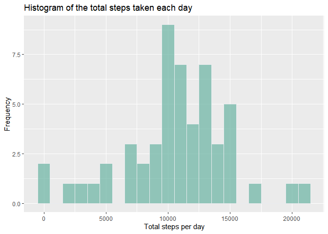

```r
library(ggplot2)
p <- ggplot(df, aes(x=x))
p + geom_histogram(binwidth=1000,
                   fill="#69b3a2",
                   color="#e9ecef",
                   alpha=0.7) +
        labs(x= "Total steps per day",
             y = "Frequency",
             title = "Histogram of the total steps taken each day")
```

## 3. Mean and median

The Mean and median number of steps taken each day can be obtained using the **summary** function (see section 7.1).

```r
summary(df$x)
```

```
##    Min. 1st Qu.  Median    Mean 3rd Qu.    Max.
##      41    8841   10765   10766   13294   21194
```

## 4. Time series plot of the average number of steps taken

For the second plot a new subsetting was made using the **aggregate** function, and then graphicated using **ggplot2**.

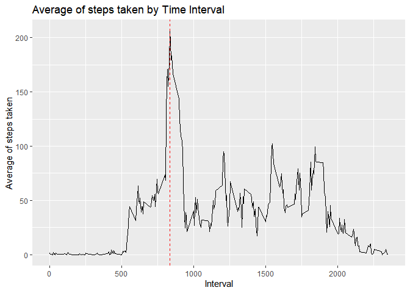

```r
## Subsetting
df2 <- aggregate(data$steps,
                 by=list(l=data$interval),
                 FUN=mean, na.rm = TRUE)

## Calculating the max
maxx <- df2$l[which.max(df2$x)]

## Plotting
p <-    ggplot(df2, aes(x = l, y = x)) +
        geom_line() +
        labs(x= "Interval", y = "Average of steps taken",
                title = "Average of steps taken by Time Interval") +
        geom_vline(xintercept= maxx, linetype="dashed", color = "red")
print(p)
```

## 5. Maximum number of steps by time interval

```r
library(lubridate)
## Calculating the max
maxx <- df2$l[which.max(df2$x)]

## Transform to hours
duration(maxx, "minutes")
```

```
## [1] "50100s (~13.92 hours)"
```

## 6. Imputing missing values

As there are days/intervals with missing values a new datasets was created. But, first the porcentage of was calculated. (Note that the total values were reported using the **summary** function in section **1**)

```r
NAt <- sum(is.na(data$steps))
t <- nrow(data)
NAp <- (NAt/t)*100
NAp
```

```
## [1] 13.11475
```

### 6.1 Filling in the missing values

The values were filled with the mean values for their respective 5-minute interval using the **mutate** function of the **dyplr** package. A new dataset identically to the original but with the missing data filled in was created.

```r
library(dplyr)
df3 <- cbind(df2$x, data)
names(df3)[names(df3) == "df2$x"] <- "MeanSteps"
df4 <- df3 %>% mutate(MissingSteps = ifelse(is.na(steps), MeanSteps, steps))
df4 <- df4[, 2:5]
head(df4)
```

```
##   steps       date interval MissingSteps
## 1    NA 2012-10-01        0    1.7169811
## 2    NA 2012-10-01        5    0.3396226
## 3    NA 2012-10-01       10    0.1320755
## 4    NA 2012-10-01       15    0.1509434
## 5    NA 2012-10-01       20    0.0754717
## 6    NA 2012-10-01       25    2.0943396
```

## 7 Histogram of the total number of steps taken each day after missing values

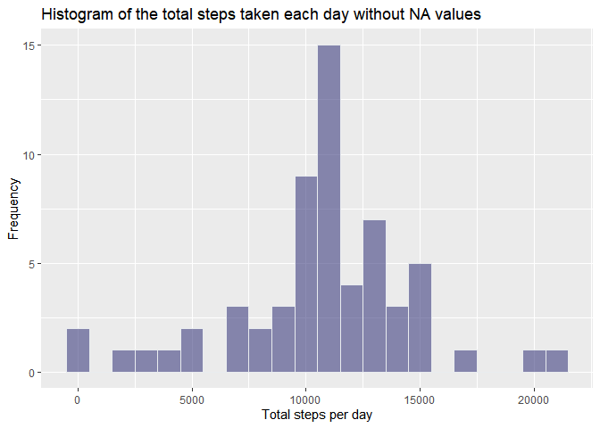

```r
df5 <- aggregate(df4$MissingSteps, by=list(date=df4$date), FUN=sum)
p <- ggplot(df5, aes(x=x))
p + geom_histogram(binwidth=1000,
                   fill="#404080",
                   color="#e9ecef",
                   alpha=0.6) +
        labs(x= "Total steps per day",
             y = "Frequency",
             title = "Histogram of the total steps taken each day without NA values")
```

### 7.1 New Mean and Median

```r
Mean <- c(mean(df$x), mean(df5$x))
Median <- c(median(df$x), median(df5$x))
Comparisson <- cbind(Mean, Median)
Comparisson
```

```
##          Mean   Median
## [1,] 10766.19 10765.00
## [2,] 10766.19 10766.19
```

## 8. Activity patterns between weekdays and weekends

To analyse the differences in the activity patterns between weekdays and weekends a new dataset was created. For this reason, the **weekdays** function was used, first converting the date to Date objects and then calculating the DayType as a factor.

```r
df4$date <- as.Date(df4$date)
day <- as.factor(weekdays(df4$date))
df6 <- cbind(df4, day)
weekend <- c("Satruday", "Sunday")
df6 <- df6 %>% mutate(DayType = ifelse(day == weekend, "Weekend", "Weekday"))
df6$DayType <- as.factor(df6$DayType)
head(df6)
```

```
##   steps       date interval MissingSteps    day DayType
## 1    NA 2012-10-01        0    1.7169811 Monday Weekday
## 2    NA 2012-10-01        5    0.3396226 Monday Weekday
## 3    NA 2012-10-01       10    0.1320755 Monday Weekday
## 4    NA 2012-10-01       15    0.1509434 Monday Weekday
## 5    NA 2012-10-01       20    0.0754717 Monday Weekday
## 6    NA 2012-10-01       25    2.0943396 Monday Weekday
```

### 8.1 Panel plot

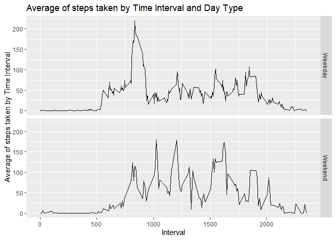

```r
df7 <- df6 %>% group_by(interval,DayType) %>% summarise(AverageSteps=mean(MissingSteps))
p <- df7 %>% ggplot(aes(x = interval, y = AverageSteps)) +
        geom_line() +
        facet_grid(DayType ~ .) +
        labs(x= "Interval", y = "Average of steps taken by Time Interval",
             title = "Average of steps taken by Time Interval and Day Type")
print(p)
```